```python
%%HTML
<script src="require.js"></script>
```

```python
from IPython.display import HTML
HTML(
    """
    <script
        src='https://cdnjs.cloudflare.com/ajax/libs/jquery/2.0.3/jquery.min.js'>
    </script>
    <script>
        code_show=true;
        function code_toggle() {
        if (code_show){
        $('div.jp-CodeCell > div.jp-Cell-inputWrapper').hide();
        } else {
        $('div.jp-CodeCell > div.jp-Cell-inputWrapper').show();
        }
        code_show = !code_show
        }
        $( document ).ready(code_toggle);
    </script>
    <form action='javascript:code_toggle()'>
        <input type="submit" value='Click here to toggle on/off the raw code.'>
    </form>
    """
)
```

[figure not shown]

# ABSTRACT

This report explores the potential cost implications, taking into account the scarcity of ingredients in the Philippines, for a range of recipes representing different cuisines and the particular components required to prepare them. It examines the viability of preparing these cuisines in the Philippines considering their costs, or from another standpoint, identifies which cuisines and recipes can be produced based on ingredient availability, with import data serving as a measure of scarcity. The group selected this topic due to the fluctuations in commodity prices, particularly in the food sector, stemming from macroeconomic factors, notably inflation. Reviewing a dataset that covers pandemic to post-pandemic import transactions will reflect the movement of commodities in the short-term. Given that global trade is dynamic and difficult to predict, this heavily impacts the culinary industry in terms of the availability and affordability of imported ingredients. In the Philippines which is widely known for vibrant culinary traditions, the group aims to answer the question: Which global cuisine's ingredients is the most costly to impost to the Philippines?  
For this analysis, the group utilized two primary datasets: (1) The PH Customs Import Datasets, encompassing all imported goods from various countries, and (2) a Recipe database featuring diverse recipes from various cuisines, along with the corresponding ingredients required for their preparation. By linking the ingredients with data related to imported goods, the group made the decision to focus on the top 20 ingredients for each cuisine. This choice was based on the fact that 50% of all recipes within each cuisine category incorporated these top 20 ingredients. While validating and consolidating the top ingredients, the group has also started cleaning the datasets using varying strenuous methods to confidently start using the data for analyses.  
The analysis confirms pork's popularity in Filipino cuisine, present in about 26% of dishes, and its high import cost. Diversifying sourcing is key to managing ingredient costs effectively, with Spain as a reliable and cost-effective pork supplier.The analysis confirms pork's popularity in Filipino cuisine, present in about 26% of dishes, and its high import cost. Diversifying sourcing is key to managing ingredient costs effectively, with Spain as a reliable and cost-effective pork supplier.  
Using these and other insights, the recommendation of the group is for the Philippines to diversify its sources of pork to mitigate the risks from potential supply disruptions and price fluctuations. Exploring new trade relationships with countries offering competitive prices, in addition to securing partnerships or agreements with Spain, can help ensure a stable and cost-effective supply of pork for Filipino cuisine ingredients.

# The Problem Statement

In the dynamic landscape of global trade, the culinary industry is deeply affected by the availability and affordability of ingredients sources from different countries of the world. In the context of the Philippines specifically, a country known for its diverse and vibrant culinary traditions, an intriguing question arises:

**Which global cuisine's ingredients is the most costly to impost to the Philippines?**

For those deeply involved in the culinary industry, such as chefs, restaurant owners, and food distributors, insights gathered from answering this problem statement can enable them to optimize their procurement processes and manage costs effectively. For cost-intensive cuisines specifically, this can even kick-start innovation efforts within the local culinary fusion scene to promote development of dishes from global cuisines with a twist: by capitalizing on locally sourced ingredients as a substitute and in turn contribute to the sustainability of producing these cuisines in the Philippines.

# Methodology

The table below displays the methodology, which details the implementation plan of the study in order to answer the problem statement presented.

**Table 1. Methodology Overview**

| Step | Description |
| --- | --- |
| Data Collection | Retrieve data from Customs and Receipe Ingredients datasets from JOJIE, create database and load data as tables |
| Data Processing | Clean missing values, and create linking tables to support consolidation of all data in the tables in preparation for exploratory data analysis |
| Exploratory Data Analysis | Perform EDA to answer the problem statement, and identify patterns/ trends of other relationships between variables |
| Results | Summarize the insights from the EDA, and provide recommendations given the insights acquired |

# A. The Data Source

Two datasets were utilized to perform the analysis. They were gathered from the JOJIE-collected public datasets via the following directory paths listed below under the Asian Institute of Management (AIM).

[figure not shown]

# B. Data Overview

Each monthly file name in the Customs Imports table contains the following columns.

**Table 2. Customs Imports Data Overview**

| Column Name | Description | Data Type |
| --- | --- | --- |
| HSCODE | Harmonized Commodity Description and Coding System; to classify goods | integer |
| COUNTRYORIGIN | Country where goods were manufactured | string |
| COUNTRYEXPORT | Country where goods were physically shipped | string |
| GROSSMASSKGS | Weight of goods (in kilograms) including packaging | float |
| NETMASSKGS | Weight of goods (in kilograms) excluding packaging | float |
| CUSTOMSVALUE | Total value of goods; determines import duty, taxes to be paid | float |
| CURRENCY | Native currency of goods | string |
| DUTIABLE_FOREIGN | Price paid or market value including tax payable; in native currency | float |
| EXHANGE_RATE | Exchange rate of goods native currency and Philippine Peso (PHP) | float |
| DUTIABLEVALUEPHP | Price paid or market value including tax payable; in PHP | float |
| FREIGHT | Freight charges; in native currency | float |
| INSURANCE | Insurance charges; in native currency; in native currency | float |
| ARRASTRE | Handling, receiving, custody of goods | float |
| PREF_CODE | Free-trade agreement/ tax-incentive used by importer | string |
| DUTY | Price including import clearance; | float |
| VATTAXBASE | Total price used as basis for computing value added tax; in PHP | float |
| VAT | Value added tax paid; in PHP | float |
| EXCISEADVALOREM | Excise tax based on selling price; Ad Valorem Tax; | float |
| DUTIESTAXES | Customs duty tax; in PHP | float |
| GOODSDESCRIPTION | Brief description of goods | string |
| UOM | Unit of measurement (e.g. Piece, Kilogram) | string |
| QUANTITY | Quantity of goods based on UOM | float |

The `train.json` file in the Recipe Ingredients dataset contains the following columns.

**Table 3. Recipe Ingredients Data Overview**

| Column Name | Description | Data Type |
| --- | --- | --- |
| id | ID of the recipe | integer |
| cuisine | Cuisine of the recipe | string |
| ingredients | Ingredients of the recipe | list of strings |

# A. Import Libraries

First, we import the following libraries to prepare for the data collection, exploration and analysis stages of the study:

- pandas
- sqlalchemy (create_engine)
- sqlite3

```python
# Import libraries
import pandas as pd
from sqlalchemy import create_engine
import sqlite3
import matplotlib.pyplot as plt
```

# B. Customs Imports Dataset Preparation

#### Load files to SQLite Database

The months of reports to be included were defined in the list. The scope was limited to the most recent files as of creation data of the report in order to capture updated import trends. The duration spans one year or twelve months worth of data, with the assumption that the duration would capture the average behavior of import trends throughout the year in case of seasonality, and that the sample would be a sufficient representation of expected import trends of goods ingredients.

```python
# Define months of files to include
months = ['Oct2022', 'Nov2022', 'Dec2022', 'Jan2023', 'Feb2023', 'March2023',
          'April2023', 'May2023', 'June2023', 'July2023', 'Aug2023', 'Sept2023']
```

Specific columns from to be loaded from the Customs Imports dataset were defined, with excluded columns to be dropped. Columns were selected based on relevancy on later exploratory data analysis and insight generation.

The following table details the reasons for why certain columns were selected or dropped.

**Table 4. Customs Imports Column Selection**

| Segment Name | Segment Description | Selected/Dropped | Columns Included |
| --- | --- | --- | --- |
| Goods Descriptors | Identifies or describes goods | Selected | HSCODE, COUNTRYEXPORT, GOODSDESCRIPTION |
| Volume | Describes volume of goods in terms of weight | Selected | GROSSMASSKGS, NETMASSKGS |
| Quantity | Describes quantity of goods; inconsistent; redundant | Dropped | UOM, QUANTITY |
| Goods Value | Describes value of goods | Selected | CUSTOMSVALUE, DUTIABLE_FOREIGN, DUTIABLEVALUEPHP, FREIGHT, INSURANCE, ARRASTRE, VATTAXBASE, DUTIESTAXES |
| Value Inferred | Redundant values; can be inferred from goods value | Dropped | PREF_CODE, DUTY, VAT, EXCISEADVALOREM |
| Value Links | Links or can transform goods values | Selected | CURRENCY, EXCHANGE_RATE |
| Others | Other data not relevant to analysis | Dropped | COUNTRYORIGIN |

```python
# Define columns to include
cols = ['HSCODE', 'COUNTRYEXPORT', 'GROSSMASSKGS', 'NETMASSKGS',
        'CUSTOMSVALUE', 'CURRENCY', 'DUTIABLE_FOREIGN', 'EXCHANGE_RATE',
        'DUTIABLEVALUEPHP', 'FREIGHT', 'INSURANCE', 'ARRASTRE', 'VATTAXBASE',
        'DUTIESTAXES', 'GOODSDESCRIPTION']
```

The database `culinary_currency.db` was created to store all data that would be analyzed for the study. The Excel files were then loaded and transformed to SQL tables under the created database. The result is twelve tables containing the data in each monthly Customs Imports, limited to the columns selected earlier.

```python
# Name the database
db_name = 'culinary_currency.db'
```

```python
# Create database
engine = create_engine(f'sqlite:///{db_name}')

# Load Customs Imports files and transform to SQLite database table
with sqlite3.connect(db_name) as conn:
    for month in months:
        df = pd.read_excel(
            '/mnt/data/public/customs/Dailyfiled'+ month +'.xlsx',
            sheet_name='Query1',
            usecols=cols)
        df.to_sql(name=month, con=conn, if_exists='replace', index=False)
```

#### Merge tables to unified table

Next is to merge each individual monthly Customs Imports table into one unified table. An additional column was first added to each monthly table to identify the month and year of where each import entry originated. Afterwards, all monthly tables were unified into the `customs_imports` table.

```python
# Add Month column to each monthly Customs Imports table
with sqlite3.connect(db_name) as conn:
    cursor = conn.cursor()
    for month in months:
        try:
            cursor.execute(
                f"""
                ALTER TABLE {month}
                ADD COLUMN Month;
                """)
            cursor.execute(
                f"""
                UPDATE {month}
                SET Month = ?""",
                (month,))
        except sqlite3.OperationalError as e:
            continue

# Join the twelve monthly tables into one unified Customs Imports Table
def unify_tables(db_name, unified_table_name, tables):
    """
    """
    with sqlite3.connect(db_name) as conn:
        cursor = conn.cursor()
        cursor.execute(
            f"""
            CREATE TABLE {unified_table_name} AS
            SELECT
                *
            FROM
                {tables[0]};
            """
        )
        for table in tables[1:]:
            cursor.execute(
                f"""
                INSERT INTO
                    {unified_table_name}
                SELECT
                    *
                FROM
                    {table};
                """
            )

unified_table_name = 'customs_imports'
unify_tables(db_name, unified_table_name, months)
```

A dataframe `df_customs_imports` is created and can be used to preview the unified table created.

```python
# Create dataframe from customs_imports table
with sqlite3.connect(db_name) as conn:
    df_customs_imports = pd.read_sql(
        """
        SELECT
            *
        FROM
            customs_imports
        """,
        conn)

df_customs_imports.head()
```

|  | HSCODE | COUNTRYEXPORT | GROSSMASSKGS | NETMASSKGS | CUSTOMSVALUE | CURRENCY | DUTIABLE_FOREIGN | EXCHANGE_RATE | DUTIABLEVALUEPHP | FREIGHT | INSURANCE | ARRASTRE | VATTAXBASE | DUTIESTAXES | GOODSDESCRIPTION | Month |
| --- | --- | --- | --- | --- | --- | --- | --- | --- | --- | --- | --- | --- | --- | --- | --- | --- |
| 0 | 33049990000 | HONG KONG | 70.00 | 66.50 | 1720.00 | USD | 2090.77 | 58.95 | 123250.89 | 283.74 | 35.43 | 0.0 | 132977.75 | 24584.89 | 2000 PCS LIQUID HIGHLIGHTER 337A (FIRE OPAL) | Oct2022 |
| 1 | 82055900000 | INDONESIA | 0.02 | 0.02 | 19.71 | USD | 20.03 | 58.95 | 1180.76 | 0.32 | 0.00 | 0.0 | 1822.51 | 230.97 | "PT HM" CIGARETTE MACHINE SCRAPER 3P827 | Oct2022 |
| 2 | 82055900000 | INDONESIA | 0.02 | 0.02 | 19.71 | USD | 20.03 | 58.95 | 1180.76 | 0.32 | 0.00 | 0.0 | 1822.51 | 230.97 | "PT HM" CIGARETTE MACHINE SCRAPER 3P827 | Oct2022 |
| 3 | 73182400000 | INDONESIA | 0.02 | 0.02 | 21.92 | USD | 22.28 | 58.95 | 1313.40 | 0.36 | 0.00 | 0.0 | 2084.60 | 386.66 | "PT HM" CIGARETTE MACHINE PIN 0P570 | Oct2022 |
| 4 | 84821000000 | INDONESIA | 0.14 | 0.14 | 165.12 | USD | 167.82 | 58.95 | 9892.99 | 2.68 | 0.02 | 0.0 | 10475.99 | 1257.12 | "PT HM" CIGARETTE MACHINE BALL BEARING 25081... | Oct2022 |

#### Treat missing datapoints

Next, each columns in the `df_customs_imports` was checked for any missing values to ensure data cleanliness when working on the analysis.

```python
# Check for missing datapoints
df_customs_imports.isnull().sum()
```

```
HSCODE              0
COUNTRYEXPORT       0
GROSSMASSKGS        0
NETMASSKGS          0
CUSTOMSVALUE        0
CURRENCY            0
DUTIABLE_FOREIGN    0
EXCHANGE_RATE       0
DUTIABLEVALUEPHP    0
FREIGHT             0
INSURANCE           0
ARRASTRE            0
VATTAXBASE          0
DUTIESTAXES         0
GOODSDESCRIPTION    6
Month               0
dtype: int64
```

The `GOODSDESCRIPTION` column was identified to have 6 missing datapoints. The entries were loaded to determine if the values can be imputed or if they should be outright removed.

```python
# Investigate entries with missing datapoints
df_customs_imports[df_customs_imports['GOODSDESCRIPTION'].isnull()]
```

|  | HSCODE | COUNTRYEXPORT | GROSSMASSKGS | NETMASSKGS | CUSTOMSVALUE | CURRENCY | DUTIABLE_FOREIGN | EXCHANGE_RATE | DUTIABLEVALUEPHP | FREIGHT | INSURANCE | ARRASTRE | VATTAXBASE | DUTIESTAXES | GOODSDESCRIPTION | Month |
| --- | --- | --- | --- | --- | --- | --- | --- | --- | --- | --- | --- | --- | --- | --- | --- | --- |
| 2576203 | 84669390000 | SINGAPORE | 0.83 | 0.69 | 90.00 | USD | 105.48 | 54.688 | 5768.49 | 10.98 | 1.80 | 0.0 | 6697.84 | 861.42 | None | Jan2023 |
| 5271408 | 90049090000 | SINGAPORE | 0.59 | 0.41 | 505.22 | USD | 532.23 | 55.916 | 29760.17 | 6.80 | 20.21 | 0.0 | 37289.19 | 11914.74 | None | May2023 |
| 6563518 | 42029290000 | SINGAPORE | 1.42 | 0.99 | 1260.22 | USD | 1327.67 | 55.546 | 73746.75 | 17.04 | 50.41 | 0.0 | 84940.11 | 21254.82 | None | July2023 |
| 6563520 | 42029290000 | SINGAPORE | 1.14 | 0.80 | 1008.17 | USD | 1062.13 | 55.546 | 58997.07 | 13.63 | 40.33 | 0.0 | 67977.98 | 17006.92 | None | July2023 |
| 6563521 | 42029290000 | SINGAPORE | 1.71 | 1.19 | 1512.26 | USD | 1593.19 | 55.546 | 88495.33 | 20.44 | 60.49 | 0.0 | 101900.98 | 25502.42 | None | July2023 |
| 6563523 | 42029290000 | SINGAPORE | 1.52 | 1.07 | 1350.23 | USD | 1422.49 | 55.546 | 79013.63 | 18.25 | 54.01 | 0.0 | 90997.02 | 22771.68 | None | July2023 |

The `HSCODE` of each entry was used to identify the potential nature of the `GOODSDESCRIPTION`. They were tagged on whether or not they were related to ingredients/ food.

**Table 5. Missing Datapoints Description Results**

| Index | HSCODE | Description Results | Ingredient-related? |
| --- | --- | --- | --- |
| 2576203 | 84669390000 | Other parts for machines of headings No.84.56 to 84.61Other parts for machines of headings No.84.56 to 84.61 | FALSE |
| 5271408 | 90049090000 | Other spectacles (excluding sunglasses and photochromic spectacles) | FALSE |
| 6563518 | 42029290000 | Handbags,outer Surface Not Of Leather,composition Leather,or Patent Leather,not Of Plastic Sheeting Or Textile Materials | FALSE |
| 6563520 | 42029290000 | Handbags,outer Surface Not Of Leather,composition Leather,or Patent Leather,not Of Plastic Sheeting Or Textile Materials | FALSE |
| 6563521 | 42029290000 | Handbags,outer Surface Not Of Leather,composition Leather,or Patent Leather,not Of Plastic Sheeting Or Textile Materials | FALSE |
| 6563523 | 42029290000 | Handbags,outer Surface Not Of Leather,composition Leather,or Patent Leather,not Of Plastic Sheeting Or Textile Materials | FALSE |

Since all six missing datapoints are not food-related, they will not be relevant to the analysis and are therefore safe to remove.

```python
# Remove entries with missing datapoints from df_customs_imports
df_customs_imports.dropna(subset=['GOODSDESCRIPTION'], inplace=True)

# Check for removal success
df_customs_imports.isnull().sum()
```

```
HSCODE              0
COUNTRYEXPORT       0
GROSSMASSKGS        0
NETMASSKGS          0
CUSTOMSVALUE        0
CURRENCY            0
DUTIABLE_FOREIGN    0
EXCHANGE_RATE       0
DUTIABLEVALUEPHP    0
FREIGHT             0
INSURANCE           0
ARRASTRE            0
VATTAXBASE          0
DUTIESTAXES         0
GOODSDESCRIPTION    0
Month               0
dtype: int64
```

# C. Recipe Ingredients Dataset Preparation

#### Load files to dataframe

The JSON file is first loaded to a dataframe. Because the `ingredients` column is in list form, the ingredients can be further sectioned off into individual ingredients per `id` and `cuisine` by using `explode`.

```python
# Transform JSON to dataframe and separate ingredients to individual rows
df_recipe = pd.read_json(
    '/mnt/data/public/recipe-ingredients/train.json').explode('ingredients')
df_recipe.head()
```

|  | id | cuisine | ingredients |
| --- | --- | --- | --- |
| 0 | 10259 | greek | romaine lettuce |
| 0 | 10259 | greek | black olives |
| 0 | 10259 | greek | grape tomatoes |
| 0 | 10259 | greek | garlic |
| 0 | 10259 | greek | pepper |

#### Compute contribution of top ingredients per cuisine

In order to feasibly assign an `HSCODE` to every ingredient, the scope of the ingredients to prioritize and include in the study must be defined. Upon initial check of the dataset, a total number of more than 6,700 unique ingredients were identified. The next objective is to determine the appropriate number of ingredients that would be sufficiently representative per cuisine.

```python
# Check for count of unique ingredients
print('Number of unique ingredients: ', len(df_recipe['ingredients'].unique()))
```

```
Number of unique ingredients:  6714
```

Next, the ingredients were segregated per `cuisine`, and sorted based on the number of times it has appeared in a unique recipe for said `cuisine`. Top ingredients would be prioritized to be selected as part of the representative group per `cuisine`.

```python
# Segregrate ingredients per cuisine
# Sort based on count of unique recipes that use the ingredient
df_recipe_count = (pd.DataFrame(
    df_recipe.groupby(['cuisine', 'ingredients'])['ingredients'].count())
                   .reset_index(names=['cuisine', 'ingredient_key'])
                   .sort_values(['cuisine', 'ingredients'],
                                ascending=[True, False])
                   .rename(columns={'ingredients': 'recipe_count'})
                  )

df_recipe_count.head()
```

|  | cuisine | ingredient_key | recipe_count |
| --- | --- | --- | --- |
| 674 | brazilian | salt | 194 |
| 543 | brazilian | onions | 133 |
| 539 | brazilian | olive oil | 118 |
| 468 | brazilian | lime | 89 |
| 821 | brazilian | water | 87 |

The cumulative percentage of the `recipe_count` of each ingredient versus the total `recipe_count` per `cuisine` was computed.

```python
# Compute the cumulative percentage of ingredients vs total count per cuisine
total_recipe_count = df_recipe.groupby(
    ['cuisine']).count().reset_index()[['cuisine', 'ingredients']]
df_temp = pd.merge(
    df_recipe_count, total_recipe_count, how='left', on='cuisine')
df_temp['perc_total'] = (df_temp['recipe_count'] / df_temp['ingredients'])
df_temp['cum_perc'] = df_temp.groupby('cuisine')['perc_total'].cumsum()
df_temp.columns = ['cuisine', 'ingredient_key', 'recipe_count',
                   'recipe_count_cuisine', 'perc2total', 'cum_perc']
df_temp.head()
```

|  | cuisine | ingredient_key | recipe_count | recipe_count_cuisine | perc2total | cum_perc |
| --- | --- | --- | --- | --- | --- | --- |
| 0 | brazilian | salt | 194 | 4446 | 0.043635 | 0.043635 |
| 1 | brazilian | onions | 133 | 4446 | 0.029915 | 0.073549 |
| 2 | brazilian | olive oil | 118 | 4446 | 0.026541 | 0.100090 |
| 3 | brazilian | lime | 89 | 4446 | 0.020018 | 0.120108 |
| 4 | brazilian | water | 87 | 4446 | 0.019568 | 0.139676 |

Using the cumulative percentage of the `recipe_count` per `cuisine`, the average cumulative percentage per `cuisine` was then computed depending on the number of top ingredients included, ranging from top 10 to top 50. Based on results, each `cuisine` would need to include at least 50 ingredients. This would translate to a total of 312 unique ingredients that need to assigned a corresponding `HSCODE`.

```python
# Check top recipe count per cuisine needed to get ~50%
top_count_iter = [10, 15, 20, 25, 30, 35, 40, 45, 50]
for top_count in top_count_iter:
    df_temp_top = (df_temp
                   .groupby('cuisine')
                   .head(top_count)
                   .reset_index(drop=True))
    print(top_count, ':',
          df_temp_top.groupby('cuisine')['cum_perc'].max().mean())

# Compute the total number of unique ingredients for scope of top 50 per cuisine
df_top_recipe_count = df_temp.groupby('cuisine').head(50).reset_index(drop=True)
print('Number of unique ingredients:',
      len(df_top_recipe_count['ingredient_key'].unique()))
```

```
10 : 0.23885843243697388
15 : 0.3028727304815934
20 : 0.3523184681097574
25 : 0.3913811266437274
30 : 0.42399613157655996
35 : 0.4518433052518909
40 : 0.4767548379389887
45 : 0.49916863808712775
50 : 0.519347832141478
Number of unique ingredients: 312
```

#### Standardize ingredients with similar traits

Upon investigation of the list of ingredients, it was identified that certain ingredients shared similar traits as displayed below (e.g. `onion` vs `chopped onion` vs `finely chopped onion`). From the initial `df_recipe` dataframe, ingredients sharing similar traits can be consolidated in order to (a) reduce the total count of redundant ingredients which should instead be counted as one and (b) improve the cumulative percentage of the top ingredients via consolidation.

```python
# Investigate ingredients with similar traits
df_recipe[df_recipe['ingredients']
          .str.contains('onion')]['ingredients'].unique()
```

```
array(['purple onion', 'yellow onion', 'onions', 'sliced green onions',
       'onion powder', 'green onions', 'chopped onion',
       'finely chopped onion', 'sweet onion', 'white onion',
       'minced onion', 'spring onions', 'vidalia onion', 'onion tops',
       'diced onions', 'boiling onions', 'pearl onions',
       'dried minced onion', 'onion soup', 'fresh onion',
       'diced tomatoes with garlic and onion',
       'frozen peppers and onions', 'french fried onions',
       'spanish onion', 'diced red onions', 'onion salt',
       'diced yellow onion', 'french onion soup', 'onion flakes',
       'cream cheese with chives and onion',
       'condensed french onion soup', 'onion soup mix', 'onion rings',
       'lipton recip secret golden onion soup mix', 'black onion seeds',
       'onion slices', 'onion gravy', 'pickled onion',
       'green onion bottoms', 'small yellow onion', 'cipollini onions',
       'maui onion', 'frozen onion rings', 'lipton onion soup mix',
       'bermuda onion'], dtype=object)
```

```python
# Consolidate ingredients with similar traits
df_recipe['ingredients'].replace(['sea salt','kosher salt', 'coarse salt'],
                                 'salt', inplace=True)
df_recipe['ingredients'].replace('unsalted butter', 'butter', inplace=True)
df_recipe['ingredients'].replace(['purple onion', 'scallions', 'shallots',
                                  'onions', 'finely chopped onion',
                                  'chopped onion', 'yellow onion',
                                  'white onion', 'sweet onion'],
                                 'onion', inplace=True)
df_recipe['ingredients'].replace('extra-virgin olive oil',
                                 'olive oil', inplace=True)
df_recipe['ingredients'].replace(['limes', 'lime wedges', 'fresh lime'],
                                 'lime', inplace=True)
df_recipe['ingredients'].replace('fresh lime juice', 'lime juice', inplace=True)
df_recipe['ingredients'].replace(['chopped garlic', 'garlic cloves',
                                  'minced garlic', 'large garlic cloves'],
                                 'garlic', inplace=True)
df_recipe['ingredients'].replace(['confectioners sugar', 'light brown sugar',
                                  'brown sugar', 'white sugar',
                                  'granulated sugar', 'powdered sugar'],
                                 'sugar', inplace=True)
df_recipe['ingredients'].replace('sweetened condensed milk',
                                 'condensed milk', inplace=True)
df_recipe['ingredients'].replace(['green bell pepper', 'red bell pepper'],
                                 'bell pepper', inplace=True)
df_recipe['ingredients'].replace(['black pepper', 'ground pepper',
                                  'ground black pepper',
                                  'freshly ground pepper', 'red pepper flakes',
                                  'crushed red pepper', 'ground red pepper',
                                  'crushed red pepper flakes', 'red pepper',
                                  'black peppercorns', 'white pepper',
                                  'cracked black pepper', 'green pepper',
                                  'ground white pepper'],
                                 'pepper', inplace=True)
df_recipe['ingredients'].replace(['large eggs', 'large egg yolks', 'egg yolks',
                                  'large egg whites', 'egg whites', 'eggs'],
                                 'egg', inplace=True)
df_recipe['ingredients'].replace(['sesame oil', 'peanut oil',
                                  'toasted sesame oil'],
                                 'vegetable oil', inplace=True)
df_recipe['ingredients'].replace(['oil', 'cooking spray'],
                                 'cooking oil', inplace=True)
df_recipe['ingredients'].replace('all-purpose flour',
                                 'flour', inplace=True)
df_recipe['ingredients'].replace(['corn tortillas', 'flour tortillas'],
                                 'tortilla', inplace=True)
df_recipe['ingredients'].replace(['fresh ginger', 'ground ginger',
                                  'peeled fresh ginger', 'fresh ginger root'],
                                 'ginger', inplace=True)
df_recipe['ingredients'].replace(['heavy cream', 'half & half'],
                                 'whipping cream', inplace=True)
df_recipe['ingredients'].replace(['low sodium soy sauce', 'light soy sauce'],
                                 'soy sauce', inplace=True)
df_recipe['ingredients'].replace(['whole milk', '2% reduced-fat milk',
                                  '1% low-fat milk'], 'milk', inplace=True)
df_recipe['ingredients'].replace(['cinnamon sticks', 'ground cinnamon'],
                                 'cinnamon', inplace=True)
df_recipe['ingredients'].replace('dried thyme', 'thyme', inplace=True)
df_recipe['ingredients'].replace(['white wine', 'dry white wine'],
                                 'red wine', inplace=True)
df_recipe['ingredients'].replace('fresh lemon juice',
                                 'lemon juice', inplace=True)
df_recipe['ingredients'].replace('fresh dill', 'dill', inplace=True)
df_recipe['ingredients'].replace('dijon mustard', 'mustard', inplace=True)
df_recipe['ingredients'].replace(['fresh parsley', 'flat leaf parsley',
                                  'chopped parsley', 'fresh parsley'],
                                 'parsley', inplace=True)
df_recipe['ingredients'].replace(['dried oregano'], 'oregano', inplace=True)
df_recipe['ingredients'].replace(['feta cheese crumbles', 'feta cheese',
                                  'grated parmesan cheese', 'parmesan cheese',
                                  'shredded cheddar cheese',
                                  'mozzarella cheese',
                                  'shredded mozzarella cheese', 'cream cheese',
                                  'cheddar cheese',
                                  'parmigiano reggiano cheese',
                                  'ricotta cheese'], 'cheese', inplace=True)
df_recipe['ingredients'].replace(['balsamic vinegar', 'red wine vinegar',
                                  'white wine vinegar', 'sherry vinegar',
                                  'rice vinegar', 'white vinegar',
                                  'cider vinegar'], 'vinegar', inplace=True)
df_recipe['ingredients'].replace(['ground turmeric', 'tumeric'],
                                 'turmeric', inplace=True)
df_recipe['ingredients'].replace(['cumin seed', 'ground cumin'],
                                 'cumin', inplace=True)
df_recipe['ingredients'].replace(['green chilies', 'jalapeno chilies',
                                  'red chili peppers', 'chile pepper'],
                                 'chili', inplace=True)
df_recipe['ingredients'].replace(['ground coriander'],
                                 'coriander', inplace=True)
df_recipe['ingredients'].replace('ground allspice', 'allspice', inplace=True)
df_recipe['ingredients'].replace(['sesame seeds', 'toasted sesame seeds'],
                                 'sesame seed', inplace=True)
df_recipe['ingredients'].replace('Gochujang base', 'gochujang', inplace=True)
df_recipe['ingredients'].replace(['chopped cilantro fresh', 'chopped cilantro',
                                  'fresh cilantro leaves', 'fresh cilantro',
                                  'cilantro leaves'], 'cilantro', inplace=True)
df_recipe['ingredients'].replace('saffron threads', 'saffron', inplace=True)
df_recipe['ingredients'].replace(['cherry tomatoes', 'plum tomatoes',
                                  'diced tomatoes', 'crushed tomatoes',
                                  'tomatoes'], 'tomato', inplace=True)
df_recipe['ingredients'].replace(['chicken broth', 'chicken stock',
                                  'fat free less sodium chicken broth',
                                  'low salt chicken broth',
                                  'low sodium chicken broth'],
                                 'broth', inplace=True)
df_recipe['ingredients'].replace(['dried basil', 'fresh basil',
                                  'fresh basil leaves'], 'basil', inplace=True)
df_recipe['ingredients'].replace(['boneless skinless chicken breasts',
                                  'chicken breasts',
                                  'boneless skinless chicken breast halves',
                                  'chicken thighs',
                                  'boneless chicken skinless thigh'],
                                 'chicken', inplace=True)
df_recipe['ingredients'].replace(['lean ground beef', 'ground beef'],
                                 'beef', inplace=True)
df_recipe['ingredients'].replace('ground pork', 'pork', inplace=True)
df_recipe['ingredients'].replace('cayenne', 'cayenne pepper', inplace=True)
df_recipe['ingredients'].replace(['chopped celery', 'celery ribs'],
                                 'celery', inplace=True)
df_recipe['ingredients'].replace(['spring onions', 'sliced green onions',
                                  'green onions'], 'green onion', inplace=True)
df_recipe['ingredients'].replace(['large shrimp','medium shrimp'],
                                 'shrimp', inplace=True)
df_recipe['ingredients'].replace(['potatoes', 'sweet potatoes'],
                                 'potato', inplace=True)
df_recipe['ingredients'].replace(['ground cloves', 'cloves'],
                                 'clove', inplace=True)
df_recipe['ingredients'].replace('plain yogurt', 'yogurt', inplace=True)
df_recipe['ingredients'].replace(['lemons', 'fresh lemon', 'grated lemon zest'],
                                 'lemon', inplace=True)
df_recipe['ingredients'].replace(['fresh oregano', 'chopped fresh oregano'],
                                 'oregano', inplace=True)
df_recipe['ingredients'].replace(['fresh mint', 'chopped fresh mint'],
                                 'mint', inplace=True)
df_recipe['ingredients'].replace(['chopped fresh thyme', 'fresh thyme'],
                                 'thyme', inplace=True)
df_recipe['ingredients'].replace(['hot water', 'warm water', 'cold water'],
                                 'water', inplace=True)
```

```python
# Segregrate ingredients per cuisine
# Sort based on count of unique recipes that use the ingredient
df_recipe_count = (pd.DataFrame(
    df_recipe.groupby(['cuisine', 'ingredients'])['ingredients'].count())
                   .reset_index(names=['cuisine', 'ingredient_key'])
                   .sort_values(['cuisine', 'ingredients'],
                                ascending=[True, False])
                   .rename(columns={'ingredients': 'recipe_count'})
                  )

# Compute the cumulative percentage of ingredients vs total count per cuisine
total_recipe_count = df_recipe.groupby(
    ['cuisine']).count().reset_index()[['cuisine', 'ingredients']]
df_temp = pd.merge(
    df_recipe_count, total_recipe_count, how='left', on='cuisine')
df_temp['perc_total'] = (df_temp['recipe_count'] / df_temp['ingredients'])
df_temp['cum_perc'] = df_temp.groupby('cuisine')['perc_total'].cumsum()
df_temp.columns = ['cuisine', 'ingredient_key', 'recipe_count',
                   'recipe_count_cuisine', 'perc2total', 'cum_perc']

# Check top recipe count per cuisine needed to get average of 50%
top_count_iter = [10, 15, 20, 25, 30, 35, 40, 45, 50]
for top_count in top_count_iter:
    df_temp_top = df_temp.groupby(
        'cuisine').head(top_count).reset_index(drop=True)
    print(top_count, ':',
          df_temp_top.groupby('cuisine')['cum_perc'].max().mean())

# Compute the total number of unique ingredients for scope of top 50 per cuisine
df_top_recipe_count = df_temp.groupby('cuisine').head(20).reset_index(drop=True)
print('Number of unique ingredients:',
      len(df_top_recipe_count['ingredient_key'].unique()))
```

```
10 : 0.3753891144459002
15 : 0.4567947936788431
20 : 0.5118929710381203
25 : 0.5531865204536894
30 : 0.5854376737207724
35 : 0.6110534926472158
40 : 0.6326345033070309
45 : 0.6512511200807622
50 : 0.6673310851240913
Number of unique ingredients: 84
```

#### Load dataframe to SQLite Database

Lastly, the corresponding dataframe containing the top 20 ingredients per cuisine can be transformed to a table `recipe_ingredients` in the database.

```python
# Load top ingredients dataframe and transform to SQLite database table
with sqlite3.connect(db_name) as conn:
    df_top_recipe_count.to_sql(
        name='recipe_ingredients', con=conn, if_exists='replace', index=False)
```

A dataframe `df_recipe_ingredients` is created and can be used to preview the table created.

```python
# Preview table as dataframe
df_recipe_ingredients = pd.read_sql(
    """
    SELECT
        *
    FROM
        recipe_ingredients
    """,
    conn)
df_recipe_ingredients.head()
```

|  | cuisine | ingredient_key | recipe_count | recipe_count_cuisine | perc2total | cum_perc |
| --- | --- | --- | --- | --- | --- | --- |
| 0 | brazilian | salt | 231 | 4446 | 0.051957 | 0.051957 |
| 1 | brazilian | onion | 203 | 4446 | 0.045659 | 0.097616 |
| 2 | brazilian | garlic | 186 | 4446 | 0.041835 | 0.139451 |
| 3 | brazilian | pepper | 178 | 4446 | 0.040036 | 0.179487 |
| 4 | brazilian | olive oil | 131 | 4446 | 0.029465 | 0.208952 |

# D. Creation of Consolidated Table

#### Create dictionary linking ingredient and HSCODE

A link or common key must be created in order to unify the two separate datasets before conducting the analysis. The method to be used would utilize to conditional logics:

1. Check if entries under `HSCODE` is the appropriate classification ID for the ingredient
2. Check if entries under `GOODSDESCRIPTION` contain the ingredient

Two conditions must be used to take into consideration the following instances:

1. Entries sharing the same `HSCODE` but refers to different ingredients (e.g. `lemon juice` and `lime juice`)
2. Entries with `GOODSDESCRIPTION` that contains the ingredient but do not refer to the ingredient itself (e.g. `orange` referring to orange-colored items)

A dictionary with the following characteristics was initially created to create key-value pairs between the ingredient, `HSCODE`, and search word for `GOODSDESCRIPTION`.

- key: ingredient from the `recipe_ingredients` table
- first value: list of `HSCODE` that corresponds to ingredient
- second value: keyword or search word to be used in `GOODSDESCRIPTION` that corresponds to ingredient

The methodology for populating the dictionary involves the following steps:

1. Check the top `HSCODE` that would appear when the ingredient was searched in the `GOODSDESCRIPTION` column.
2. Investigate each `HSCODE` to determine the appropriate identifier/s per ingredient.
3. Include all appropriate `HSCODE` in list as value of dictionary.

```python
# Find top HSCODE per ingredient e.g. salt
ingredient = 'SALT'

(df_customs_imports[df_customs_imports['GOODSDESCRIPTION']
                    .str.contains(ingredient)]
 .groupby('HSCODE')['GOODSDESCRIPTION']
 .count()
 .sort_values(ascending=False)
 [:10])
```

```
HSCODE
4051000000     850
20081999000    316
20052019000    233
25010099000    176
25010010000    156
38089319000    144
38249999000    122
38210090000    113
21039029000    109
29349910000    108
Name: GOODSDESCRIPTION, dtype: int64
```

```python
# Investigate entries given ingredient and HSCODE
# Example of unsuccessful HSCODE match
hscode = '4051000000'

(df_customs_imports[df_customs_imports['GOODSDESCRIPTION']
                    .str.contains(ingredient) &
                    df_customs_imports['HSCODE'].astype('str')
                    .str.startswith(hscode)]
 .iloc[:5, -2:])
```

|  | GOODSDESCRIPTION | Month |
| --- | --- | --- |
| 161567 | 36 CT ANCHOR UNSALTED CREAMERY BUTTER EACH 20 ... | Oct2022 |
| 161568 | 240 CT ANCHOR UNSALTED CREAMERY BUTTER EACH 25... | Oct2022 |
| 267059 | ANCHOR SALTED CREAMERY BUTTER | Oct2022 |
| 275372 | ANCHOR UNSALTED CREAMERY BUTTER | Oct2022 |
| 276586 | ANCHOR UNSALTED CREAMERY BUTTER | Oct2022 |

```python
# Investigate entries given ingredient and HSCODE
# Example of successful HSCODE match
hscode = '25010099000'

(df_customs_imports[df_customs_imports['GOODSDESCRIPTION']
                    .str.contains(ingredient) &
                    df_customs_imports['HSCODE'].astype('str')
                    .str.startswith(hscode)]
 .iloc[:5, -2:])
```

|  | GOODSDESCRIPTION | Month |
| --- | --- | --- |
| 102179 | SB SUPPLEMENTATION SALT | Oct2022 |
| 112630 | SB SUPPLEMENTATION SALT | Oct2022 |
| 129697 | SB SUPPLEMENTATION SALT | Oct2022 |
| 245365 | 3.00 PE SATURATED SALT SOLUTION | Oct2022 |
| 255621 | PIAZZOLLA SALI SALE MARINO GROSSO IODATO (IODI... | Oct2022 |

With the methodology to populate the dictionary conducted, the following dictionary `ingredients_hscode_dict` is created.

```python
# Create the dictionary
ingredients_hscode_dict = {
    "salt": (["25010099000", "25010010000", "25010050000"], "%salt%"),
    "onion": (["7031019000", "7108000000", "7031029000"], "%onion%"),
    "garlic": (["7032090000"], "%garlic%"),
    "pepper": (["9041120000", "9041290000", "9041220000", "9041210000",
                "9041190000", "9041110000"], "%pepper%"),
    "olive oil": (["15099091000", "15092010000", "15099099000", "15092090000",
                   "15109090000", "15099019000", "15093000000", "15099011000",
                   "15179069000", "15141990000", "15152999000", "15094000000",
                   "15159099000", "15121990000", "15101000000", "15162033000",
                   "15141920000", "15179090000", "15180019000"], "%olive%oil%"),
    "sugar": (["17019910100", "17019910300", "17019910200", "17011400100",
               "17019100100", "17019990100", "17019910400", "17019990200",
               "17011400200", "17019100300", "17011200100", "17011200100"],
              "%sugar%"),
    "lime": (["8055020000"], "%lime%"),
    "tomato": (["20021000000"], "%tomato%"),
    "butter": (["4051000000", "4059030000", "4059010000", "4052000000"],
               "%butter%"),
    "cachaca": (["22087010000"], "%cachaca%"),
    "condensed milk": (["4029900000", "33021090000", "19019031000",
                        "19019039000", "21069099000", "4011090000",
                        "4021099000", "4015090000", "4022990000",
                        "19019019000"], "%condense%milk%"),
    "bell pepper": (["20059990000", "20019090000", "9042190000",
                     "9109990000", "9042210000", "9042290000"],
                    "%bell%pepper%"),
    "coconut milk": (["8011990000", "21069099000"], "%coconut%milk%"),
    "milk": (["4012010000", "4012090000", "22029920000", "4012090000"],
             "%milk%"),
    "parsley": (["21069089000", "7129090000", "7123990000"], "%parsley%"),
    "lime juice": (["20099091000", "20093100000", "15119020000",
                    "15079090000"], "%lime%juice%"),
    "cheese": (["4062090000", "4063000000", "4061010000", "4069000000",
                "4064000000"], "%cheese%"),
    "flour": (["11010019000", "11010011000", "11010019100", "11010011100"],
              "%flour%"),
    "whipping cream": (["4015010000", "4015090000", "4014090000", "4012090000"
                        , "21069049000", "21069099000", "21069030000",
                        "21069092000"], "%whip%cream%"),
    "baking powder": (["21023000000"], "%baking%powder%"),
    "baking soda": (["28363000000", "21023000000"], "%baking%soda%"),
    "potato": (["7019010100", "7019090200"], "%potato%"),
    "cinnamon": (["9062000000", "9061900000", "9061100000"], "%cinnamon%"),
    "vegetable oil": (["15179069000", "15162019000", "15119036000",
                       "15141990000", "15159099000", "15119039000",
                       "15162047000", "15179090000", "15099099000",
                       "15119037000", "15162034000", "15180039000",
                       "15179043000", "15119037000", "15162022000",
                       "15159039000", "15159039000", "15152999000",
                       "15149990000", "15141920000", "15131190000",
                       "15162026000", "15119049000", "15152991000"],
                      "%vegetable%oil%"),
    "carrots": (["7108000000", "7129090000"], "%carrot%"),
    "vanilla extract": (["13021990000", "13023990000"], "%vanilla%extract%"),
    "celery": (["33021090000"], "%celery%"),
    "thyme": (["9109910000", "9109990000"], "%thyme%"),
    "shrimp": (["3061722000", "3061729000", "3061721000", "3061719000",
                "3061790000", "3061711000", "3061600000", "3061730000"],
               "%shrimp%"),
    "broth": (["21041019000", "21041099000", "21039029000", "21061000200",
               "21042099000", "21061000000", "21069069000", "21069098000",
               "21069099000", "21069091000", "21069072000", "21041011000"],
              "%broth%"),
    "cayenne pepper": (["9109990000"], "%cayenne%pepper%"),
    "green onion": (["7122000000"], "%green%onion%"),
    "cajun seasoning": (["21039029000"],
                        "%%cajun%season%"),
    "soy sauce": (["21031000000", "21039029000", "21039013000"],
                  "%soy%sauce%"),
    "ginger": (["9101200000", "9101100000"], "%ginger%"),
    "corn starch": (["11081200000"], "%corn%starch%"),
    "vinegar": (["22090000000"], "%vinegar%"),
    "chicken": (["7032090000"], "%chicken%"),
    "cooking oil": (["15119036000", "15099099000", "15149990000"],
                    "%cooking%oil%"),
    "oyster sauce": (["21039013000", "21039019000", "21039029000",
                      "21031000000"], "%oyster%sauce%"),
    "hoisin sauce": (["21039013000", "21039019000", "21039011000"],
                     "%hoisin%sauce%"),
    "fish sauce": (["21039012000", "21039019000", "21069098000", "21039029000",
                    "21039013000"], "%fish%sauce%"),
    "bay leaves": (["9109910000", "9109190000", "9109990000"],
                   "%bay%lea%"),
    "pork": (["2064900000", "2032900200", "2091000000", "2032900100",
              "2064100000", "2032100200", "2032200200", "2032200100",
              "2032100100", "2031900200", "2031200200", "2031900100",
              "2062900000", "2062100000", "2023000000", "2062200000",
              "2069000000", "2061000000", "2031100100"], "%pork%"),
    "red wine": (["22042111000", "22042911000", "22042121000", "22042211000",
                  "22042113000", "22042122000", "22041000000", "22042921000",
                  "22042922000", "22043010000"], "%red%wine%"),
    "lemon juice": (["20093900100", "20099091000", "21069099200", "20098999000",
                     "20093900100", "21069055000", "21069099200"],
                    "%lemon%juice%"),
    "oregano": (["9109990000", "6039000000"], "%oregano%"),
    "lemon": (["8055010000", "8051010000", "8055020000"], "%lemon%"),
    "dill": (["9109190000", "9109990000"], "%dill%"),
    "cumin": (["9093100000"], "%cumin%"),
    "turmeric": (["9103000000", "9109190000", "9101200000", "9101200000"],
                 "%turmeric%"),
    "garam masala": (["9109190000", "9109990000"], "%garam%masala%"),
    "chili": (["9041290000", "9042290000", "9041290000", "9042190000"],
              "%chili%"),
    "coriander": (["9092200000", "9096190000", "9092100000"], "%coriander%"),
    "chili powder": (['21039029000', '9042210000', '9042290000', '9041290000',
                      '9042190000', '39231090000', '61091010000', '61099010000',
                      '61099020000'], "%chili%powder%"),
    "buttermilk": (["4039010000", "4039090000", "4021049000"], "%butter%milk%"),
    "allspice": (["9109190000", "9041190000", "9109990000", "94016100000"],
                 "%all%spice%"),
    "mirin": (["21039013000", "22060020000", "22060091000", "21039019000"],
              "%mirin%"),
    "sake": (["22060020000", "21039029000"], "%sake%"),
    "sesame seed": (["12074090000", "21039029000", "20081991000", "20081999000",
                     "12074010000", "20079990000", "9041290000", "9096290000",
                     "12099190000"], "%sesame%seed%"),
    "dashi": (["21039019000", "33021090000", "21039019000"], "%dashi%"),
    "gochujang": (["21039029000", "21039019000",  "21039013000", "19019099000",
                   "21039011000", "21039029300"], "%gochujang%"),
    "kimchi": (["20059990000", "20059910000", "20059990300", "7109000000"],
               "%kimchi%"),
    "honey": (["4090000000"], "%honey%"),
    "beef": (["2023000000", "15029010000", "2022000000", "2062900000"],
             "%beef%"),
    "tortilla": (["19059090000", "19059080000", "19041090000", "20052019000",
                  "11022000000", "11022000100", "19059010000", "19054090000",
                  "19012010000"], "%tortilla%"),
    "sour cream": (["4039090000"], "%sour%cream%"),
    "avocado": (["8119000000", "8044000000", "20089990000"], "%avocado%"),
    "salsa": (["21039019000", "21039013000", "21039029000", "21032000000",
               "21039011000"], "%salsa%"),
    "paprika": (["9042290000", "9041190000", "9042190000", "9041190000",
                 "9042110000"], "%paprika%"),
    "couscous": (["19024000000", "19049090000"], "%couscous%"),
    "beets": (["21069071000"], "%beet%"),
    "saffron": (["9109990000", "9102000000"], "%saffron%"),
    "lemongrass": (["33021090000"], "%lemon%grass%"),
}
```

The dictionary can then be transformed into an SQL table `ingredients_hscode` within the `culinary_currency` database. Each row will contain the `ingredient_key`, the `HSCODE`, and the search word in Regex form. For `ingredient_key`s with multiple `HSCODE` values available, they will appear as a separate row entry per individual `HSCODE` in the new table.

```python
# Create the table to link ingredient to corresponding HSCODE and search word
with sqlite3.connect(db_name) as conn:
    cursor = conn.cursor()
    cursor.execute(
        """
        DROP TABLE IF EXISTS ingredients_hscode
        """
    )
    cursor.execute(
        """
        CREATE TABLE IF NOT EXISTS ingredients_hscode (
            ingredient_key TEXT,
            HSCODE TEXT,
            regex_keyword TEXT)
        """
    )
    for ingredient_key, (
        hscode_list, regex_keyword) in ingredients_hscode_dict.items():
        for hscode in hscode_list:
            cursor.execute(
                """
                INSERT INTO ingredients_hscode (
                    ingredient_key,
                    HSCODE,
                    regex_keyword)
                VALUES (?, ?, ?)
                """,
                (ingredient_key, hscode, regex_keyword)
            )
```

A dataframe `df_ingredients_hscode` is created and can be used to preview the table created.

```python
# Preview table as dataframe
df_ingredients_hscode = pd.read_sql(
    """
    SELECT
        *
    FROM
        ingredients_hscode
    """,
    conn)

df_ingredients_hscode.head()
```

|  | ingredient_key | HSCODE | regex_keyword |
| --- | --- | --- | --- |
| 0 | salt | 25010099000 | %salt% |
| 1 | salt | 25010010000 | %salt% |
| 2 | salt | 25010050000 | %salt% |
| 3 | onion | 7031019000 | %onion% |
| 4 | onion | 7108000000 | %onion% |

#### Create Consolidated table

The final table to create is the `consolidated` table that will link the `customs_imports`, `recipe_ingredients` and `ingredients_hscode` together and will be utilized heavily for exploratory data analysis.

First, another table is created that will utilize the `ingredients_HSCODE` table and determine all row entries found in `customs_imports` that satisfy these two conditions:

1. `HSCODE` in both tables match with each other
2. The `regex_keyword` in `ingredients_HSCODE` is contained in the `GOODSDESCRIPTION` column from the `customs_imports` table

After which, each row entry that satisfies those two conditions are joined to the corresponding `ingredients_HSCODE` entry.

```python
# Create a table that identifies all valid customs_imports entries
with sqlite3.connect(db_name) as conn:
    cursor = conn.cursor()
    cursor.execute(
        """
        DROP TABLE IF EXISTS ingred_customs
        """
    )
    cursor.execute(
        """
        CREATE TABLE ingred_customs AS
        SELECT
            *
        FROM
            ingredients_hscode i
        LEFT JOIN
            customs_imports m
        ON
            i.HSCODE = m.HSCODE
        WHERE
            GOODSDESCRIPTION LIKE regex_keyword
        """
    )
```

A dataframe `df_ingred_customs` is created and can be used to preview the table created.

```python
# Preview table as dataframe
df_ingred_customs = pd.read_sql(
    """
    SELECT
        *
    FROM
        ingred_customs
    """,
    conn)

df_ingred_customs.head()
```

|  | ingredient_key | HSCODE | regex_keyword | HSCODE:1 | COUNTRYEXPORT | GROSSMASSKGS | NETMASSKGS | CUSTOMSVALUE | CURRENCY | DUTIABLE_FOREIGN | EXCHANGE_RATE | DUTIABLEVALUEPHP | FREIGHT | INSURANCE | ARRASTRE | VATTAXBASE | DUTIESTAXES | GOODSDESCRIPTION | Month |
| --- | --- | --- | --- | --- | --- | --- | --- | --- | --- | --- | --- | --- | --- | --- | --- | --- | --- | --- | --- |
| 0 | salt | 25010099000 | %salt% | 25010099000 | AUSTRALIA | 1720.34 | 1498.59 | 1100.00 | USD | 1189.87 | 56.908 | 67713.13 | 67.66 | 22.21 | 1225.62 | 73551.17 | 12212.27 | COLES BRAND HIMALAYAN PINK SALT 100G (220CARTONS) | Sept2023 |
| 1 | salt | 25010099000 | %salt% | 25010099000 | AUSTRALIA | 13600000.00 | 13600000.00 | 795600.00 | USD | 795600.00 | 54.576 | 43420665.60 | 0.00 | 0.00 | 1496000.00 | 45439671.43 | 0.00 | CRUDE SOLAR MARINE SALT IN BULK | April2023 |
| 2 | salt | 25010099000 | %salt% | 25010099000 | AUSTRALIA | 16500000.00 | 16500000.00 | 568602.94 | USD | 965250.00 | 56.702 | 54731605.50 | 385275.00 | 11372.06 | 2458500.00 | 57869575.01 | 0.00 | 16,500 MT CRUDE SOLAR MARINE SALT IN BULK | Sept2023 |
| 3 | salt | 25010099000 | %salt% | 25010099000 | AUSTRALIA | 16500000.00 | 16500000.00 | 825000.00 | USD | 1143191.18 | 56.702 | 64821226.29 | 305250.00 | 12941.18 | 1815000.00 | 67284582.82 | 0.00 | 16,500 MT CRUDE SOLAR MARINE SALT IN BULK | Aug2023 |
| 4 | salt | 25010099000 | %salt% | 25010099000 | CANADA | 270.96 | 211.00 | 845.60 | USD | 973.82 | 56.678 | 55194.17 | 94.40 | 33.82 | 178.55 | 58696.28 | 9803.49 | 20 CTNS. HIMALAYAN SALT GLUTEN-FREE (HEALTHY O... | Aug2023 |

Finally, the `consolidated` table is created by joining the `ingred_customs` table and the `recipe_ingredients` table. The target is to link to each cuisine-ingredient pair all corresponding customs row entries that match according to the identified `ingredient_key`.

```python
with sqlite3.connect(db_name) as conn:
    cursor = conn.cursor()
    cursor.execute(
        """
        DROP TABLE IF EXISTS consolidated
        """
    )
    cursor.execute(
        """
        CREATE TABLE consolidated AS
        SELECT
            Month, r.cuisine, r.ingredient_key, GOODSDESCRIPTION, i.HSCODE,
            COUNTRYEXPORT, GROSSMASSKGS, NETMASSKGS, CUSTOMSVALUE,
            CURRENCY, DUTIABLE_FOREIGN, EXCHANGE_RATE, DUTIABLEVALUEPHP,
            FREIGHT, INSURANCE, ARRASTRE, VATTAXBASE, DUTIESTAXES,
            recipe_count, recipe_count_cuisine
        FROM
            recipe_ingredients r
        LEFT JOIN
            ingred_customs i
        ON
            r.ingredient_key = i.ingredient_key
        """
    )
```

Finally the dataframe `df_consolidated` is created and can be used to preview the table created.

```python
# Preview consolidated dataframe
df_consolidated = pd.read_sql(
    """
    SELECT
        *
    FROM
        consolidated
    """,
    conn)

df_consolidated.head()
```

|  | Month | cuisine | ingredient_key | GOODSDESCRIPTION | HSCODE | COUNTRYEXPORT | GROSSMASSKGS | NETMASSKGS | CUSTOMSVALUE | CURRENCY | DUTIABLE_FOREIGN | EXCHANGE_RATE | DUTIABLEVALUEPHP | FREIGHT | INSURANCE | ARRASTRE | VATTAXBASE | DUTIESTAXES | recipe_count | recipe_count_cuisine |
| --- | --- | --- | --- | --- | --- | --- | --- | --- | --- | --- | --- | --- | --- | --- | --- | --- | --- | --- | --- | --- |
| 0 | April2023 | brazilian | salt | MOLINA SUNBEST IODIZED SEA SALT GRINDER, 110G/... | 25010010000 | CHINA | 1800.0 | 792.0 | 3384.0 | USD | 3606.05 | 54.429 | 196273.69 | 154.37 | 67.68 | 501.80 | 205899.38 | 32562.67 | 231 | 4446 |
| 1 | June2023 | brazilian | salt | MOLINA SUNBEST IODIZED SEA SALT GRINDER, 110G/... | 25010010000 | CHINA | 1800.0 | 792.0 | 3600.0 | USD | 3893.03 | 56.042 | 218173.18 | 221.03 | 72.00 | 705.17 | 229033.20 | 36210.98 | 231 | 4446 |
| 2 | Jan2023 | brazilian | salt | MOLINA SUNBEST IODIZED SEA SALT GRINDER, 110G/... | 25010010000 | CHINA | 2400.0 | 1056.0 | 4512.0 | USD | 4813.29 | 55.176 | 265578.08 | 211.05 | 90.24 | 673.31 | 278374.24 | 44027.91 | 231 | 4446 |
| 3 | Nov2022 | brazilian | salt | MOLINA SUNBEST IODIZED SEA SALT GRINDER 110Gx24 | 25010010000 | CHINA | 3000.0 | 1320.0 | 5640.0 | USD | 6263.60 | 58.288 | 365092.72 | 510.80 | 112.80 | 976.28 | 381790.45 | 60418.85 | 231 | 4446 |
| 4 | Sept2023 | brazilian | salt | 600 CARTONS STC EDIBLE SALT HS CODE 2501001 | 25010010000 | CHINA | 16300.0 | 15696.0 | 4401.0 | USD | 5977.04 | 56.702 | 338910.12 | 1400.00 | 176.04 | 4738.00 | 367401.06 | 61033.23 | 231 | 4446 |

# Exploratory Data Analysis

# A. Initial Guide Questions

To guide the implementation of the exploratory data analysis, the following questions were asked:

1. Which cuisine is the most costly in terms of overall import costs?
2. Which cuisine is the most costly in terms of import costs per weight?
3. Which ingredient is the most costly in terms of import costs per weight for the top 1 costly cuisine?

Given the guide questions, the initial exploration of the data analysis involves the following steps:

1. Compute for the total costs per cuisine and their percent contribution
2. Compute for total costs per kgs cuisine and their percent distribution
3. Identify top 5 ingredients for top cuisine

#### Compute for the total costs per cuisine and their percent contribution

Firstly the total import costs were defined as the following relevant variables:

- `INSURANCE` (in native currency)
- `ARRASTRE` (in native currency)
- `VATTAXBASE` (in Philippine Peso)
- `DUTIESTAXES` (in Philippine Peso)

The `INSURANCE` and `ARRASTRE` would then be multiplied by the `EXCHANGE_RATE` variable to convert it to Philippine Peso.

```python
# Compute for total costs per cuisine, percent distribution
df_cost_total = pd.read_sql(
    """
    WITH TotalCosts AS (
        SELECT
            cuisine,
            SUM(INSURANCE * EXCHANGE_RATE + ARRASTRE * EXCHANGE_RATE
            + VATTAXBASE + DUTIESTAXES) AS TOTAL_COSTS
        FROM consolidated
        GROUP BY cuisine
    )
    SELECT
        TC.cuisine,
        TC.TOTAL_COSTS,
        (TC.TOTAL_COSTS / SUM(TC.TOTAL_COSTS) OVER ()) * 100
            AS TOTAL_COST_PERCENT
    FROM TotalCosts AS TC
    ORDER BY
        TOTAL_COST_PERCENT desc;
    """,
    conn)

df_cost_total.head(10)
```

|  | cuisine | TOTAL_COSTS | TOTAL_COST_PERCENT |
| --- | --- | --- | --- |
| 0 | filipino | 1.478679e+11 | 9.187812 |
| 1 | southern_us | 1.088570e+11 | 6.763858 |
| 2 | korean | 1.039716e+11 | 6.460302 |
| 3 | british | 9.997934e+10 | 6.212243 |
| 4 | irish | 9.700408e+10 | 6.027375 |
| 5 | brazilian | 9.227137e+10 | 5.733306 |
| 6 | italian | 8.641234e+10 | 5.369254 |
| 7 | russian | 8.532014e+10 | 5.301390 |
| 8 | french | 8.498967e+10 | 5.280856 |
| 9 | greek | 8.341528e+10 | 5.183031 |

Based on the results of the analysis, `Filipino` cuisine ranks the highest amongst other cuisines based on total import cost, at **9.19%** percent distribution, with a significant difference from the next highest cuisine (`Southern US` at 6.76%).

#### Compute for total costs per kgs cuisine and their percent distribution

Next, using the same calculation to compute for the total import costs earlier, the costs per kgs is calculated by dividing the summation with two variables: `GROSSMASSKGS` and `NETMASSKGS`, and taking the percentage distribution.

```python
# Compute for total costs per kgs cuisine, percent distribution
df_mass_total = pd.read_sql(
    """
    WITH TotalCosts AS (
        SELECT
            cuisine,
            SUM(INSURANCE * EXCHANGE_RATE + ARRASTRE * EXCHANGE_RATE
            + VATTAXBASE + DUTIESTAXES) AS TOTAL_IMPORT_COST,
            SUM(GROSSMASSKGS) AS TOTAL_GROSS_MASS,
            SUM(NETMASSKGS) AS TOTAL_NET_MASS
        FROM
            consolidated
        GROUP BY
            cuisine
    )
    SELECT
        TC.cuisine,
        TC.TOTAL_IMPORT_COST / TC.TOTAL_GROSS_MASS AS COST_PER_GROSSMASS,
        (TC.TOTAL_GROSS_MASS / SUM(TC.TOTAL_GROSS_MASS) OVER ()) * 100
        AS COST_PER_GROSSMASS_PERCENT,
        TC.TOTAL_IMPORT_COST / TC.TOTAL_NET_MASS AS COST_PER_NETMASS,
        (TC.TOTAL_GROSS_MASS / SUM(TC.TOTAL_GROSS_MASS) OVER ()) * 100
        AS COST_PER_NETMASS_PERCENT
    FROM
        TotalCosts AS TC
    ORDER BY
        COST_PER_NETMASS_PERCENT desc;
    """, conn)

df_mass_total.head(10)
```

|  | cuisine | COST_PER_GROSSMASS | COST_PER_GROSSMASS_PERCENT | COST_PER_NETMASS | COST_PER_NETMASS_PERCENT |
| --- | --- | --- | --- | --- | --- |
| 0 | filipino | 64.722836 | 6.787011 | 65.911924 | 6.787011 |
| 1 | southern_us | 56.809897 | 5.692387 | 57.695201 | 5.692387 |
| 2 | british | 52.464683 | 5.661159 | 53.275721 | 5.661159 |
| 3 | irish | 51.118756 | 5.637310 | 51.857661 | 5.637310 |
| 4 | russian | 46.016260 | 5.508107 | 46.686597 | 5.508107 |
| 5 | french | 46.505135 | 5.429094 | 47.230344 | 5.429094 |
| 6 | brazilian | 51.094188 | 5.364850 | 51.897589 | 5.364850 |
| 7 | korean | 57.702402 | 5.352823 | 58.340576 | 5.352823 |
| 8 | italian | 49.970347 | 5.137189 | 50.496847 | 5.137189 |
| 9 | chinese | 42.373545 | 5.132527 | 42.743060 | 5.132527 |

#### Identify top 5 ingredients for top cuisine

```python
# Identify top 5 ingredients for top cuisine (Filipino)
df_top5_ing_top1_cuisine = pd.read_sql(
    """
    WITH RankedIngredients AS (
        SELECT
            cuisine,
            ingredient_key,
            SUM((INSURANCE * EXCHANGE_RATE + ARRASTRE * EXCHANGE_RATE
            + VATTAXBASE + DUTIESTAXES) / NETMASSKGS) AS COST_PER_NETMASS,
        RANK() OVER (
            PARTITION BY
                cuisine
            ORDER BY
                SUM((INSURANCE * EXCHANGE_RATE + ARRASTRE * EXCHANGE_RATE +
                VATTAXBASE + DUTIESTAXES) / NETMASSKGS) DESC)
                    AS ingredient_rank
        FROM consolidated
        GROUP BY
            cuisine,
            ingredient_key
        )
    SELECT
        cuisine,
        ingredient_key,
        COST_PER_NETMASS
    FROM
        RankedIngredients
    WHERE
        ingredient_rank <= 5 AND
        cuisine LIKE 'filipino'
    ORDER BY
        COST_PER_NETMASS desc;
    """,
    conn)

df_top5_ing_top1_cuisine
```

|  | cuisine | ingredient_key | COST_PER_NETMASS |
| --- | --- | --- | --- |
| 0 | filipino | pork | 5.477061e+06 |
| 1 | filipino | salt | 5.943164e+05 |
| 2 | filipino | pepper | 3.990311e+05 |
| 3 | filipino | soy sauce | 2.769034e+05 |
| 4 | filipino | vinegar | 2.021538e+05 |

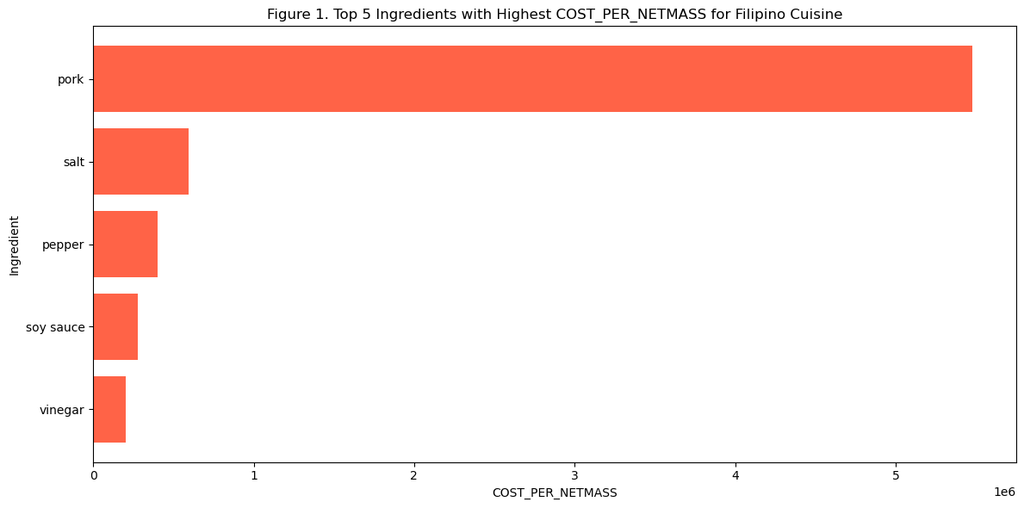

```python
plt.figure(figsize=(12, 6))
plt.barh(df_top5_ing_top1_cuisine['ingredient_key'],
         df_top5_ing_top1_cuisine['COST_PER_NETMASS'], color='tomato')
plt.xlabel('COST_PER_NETMASS')
plt.ylabel('Ingredient')
plt.title('Figure 1. Top 5 Ingredients with Highest COST_PER_NETMASS for '
          'Filipino Cuisine')
plt.gca().invert_yaxis()
plt.tight_layout()
plt.show()
```

Upon ranking all top ingredients defining the `Filipino` cuisine, `pork` ranked the highest in terms of costs per kgs, and likely a significant factor as to why `Filipino` cuisine ranked first for import costs in total.

In conclusion, the following initial insights were gathered:

- **Filipino cuisine's ingredients are the most costly to import both in terms of total cost and cost per kgs**
- **Pork is the most costly ingredient under the Filipino cuisine umbrella in terms of cost per kgs**